# Intro to DS - PCA / PCR

Michael Womble

today

# USDA Nutrient Dataset

This data was from USDA National Nutrient dataset, pre-processed by @craigkelly from data.world.

## Preparation

### Question 1

**Import the dataset**  
Import the dataset into R. There should be 45 variables. Take a quick look at the data. Just str, head, and tail will do for now.

```r
nutrient<-data.frame(read.csv('USDANationalNutrient.csv'))
str(nutrient)
```

```
## 'data.frame':    8618 obs. of  45 variables:
##  $ ID              : int  1001 1002 1003 1004 1005 1006 1007 1008 1009 1010 ...
##  $ FoodGroup       : chr  "Dairy and Egg Products" "Dairy and Egg Products" "Dairy and Egg Products" "Dairy and Egg Products" ...
##  $ ShortDescrip    : chr  "BUTTER,WITH SALT" "BUTTER,WHIPPED,WITH SALT" "BUTTER OIL,ANHYDROUS" "CHEESE,BLUE" ...
##  $ Descrip         : chr  "Butter, salted" "Butter, whipped, with salt" "Butter oil, anhydrous" "Cheese, blue" ...
##  $ CommonName      : chr  "" "" "" "" ...
##  $ MfgName         : chr  "" "" "" "" ...
##  $ ScientificName  : chr  "" "" "" "" ...
##  $ Energy_kcal     : num  717 717 876 353 371 334 300 376 406 387 ...
##  $ Protein_g       : num  0.85 0.85 0.28 21.4 23.24 ...
##  $ Fat_g           : num  81.1 81.1 99.5 28.7 29.7 ...
##  $ Carb_g          : num  0.06 0.06 0 2.34 2.79 0.45 0.46 3.06 1.33 4.78 ...
##  $ Sugar_g         : num  0.06 0.06 0 0.5 0.51 0.45 0.46 0 0.28 0 ...
##  $ Fiber_g         : num  0 0 0 0 0 0 0 0 0 0 ...
##  $ VitA_mcg        : num  684 684 840 198 292 174 241 271 263 233 ...
```

[output cut: 31 more lines]

```r
xkabledplyhead(nutrient, title = 'Nutrient Data Frame Head')
```

Nutrient Data Frame Head

| ID | FoodGroup | ShortDescrip | Descrip | CommonName | MfgName | ScientificName | Energy_kcal | Protein_g | Fat_g | Carb_g | Sugar_g | Fiber_g | VitA_mcg | VitB6_mg | VitB12_mcg | VitC_mg | VitE_mg | Folate_mcg | Niacin_mg | Riboflavin_mg | Thiamin_mg | Calcium_mg | Copper_mcg | Iron_mg | Magnesium_mg | Manganese_mg | Phosphorus_mg | Selenium_mcg | Zinc_mg | … |
| --- | --- | --- | --- | --- | --- | --- | --- | --- | --- | --- | --- | --- | --- | --- | --- | --- | --- | --- | --- | --- | --- | --- | --- | --- | --- | --- | --- | --- | --- | --- |
| 1001 | Dairy and Egg Products | BUTTER,WITH SALT | Butter, salted |  |  |  | 717 | 0.85 | 81.1 | 0.06 | 0.06 | 0 | 684 | 0.003 | 0.17 | 0 | 2.32 | 3 | 0.042 | 0.034 | 0.005 | 24 | 0.000 | 0.02 | 2 | 0.000 | 24 | 1.0 | 0.09 | … |
| 1002 | Dairy and Egg Products | BUTTER,WHIPPED,WITH SALT | Butter, whipped, with salt |  |  |  | 717 | 0.85 | 81.1 | 0.06 | 0.06 | 0 | 684 | 0.003 | 0.13 | 0 | 2.32 | 3 | 0.042 | 0.034 | 0.005 | 24 | 0.016 | 0.16 | 2 | 0.004 | 23 | 1.0 | 0.05 | … |
| 1003 | Dairy and Egg Products | BUTTER OIL,ANHYDROUS | Butter oil, anhydrous |  |  |  | 876 | 0.28 | 99.5 | 0.00 | 0.00 | 0 | 840 | 0.001 | 0.01 | 0 | 2.80 | 0 | 0.003 | 0.005 | 0.001 | 4 | 0.001 | 0.00 | 0 | 0.000 | 3 | 0.0 | 0.01 | … |
| 1004 | Dairy and Egg Products | CHEESE,BLUE | Cheese, blue |  |  |  | 353 | 21.40 | 28.7 | 2.34 | 0.50 | 0 | 198 | 0.166 | 1.22 | 0 | 0.25 | 36 | 1.016 | 0.382 | 0.029 | 528 | 0.040 | 0.31 | 23 | 0.009 | 387 | 14.5 | 2.66 | … |
| 1005 | Dairy and Egg Products | CHEESE,BRICK | Cheese, brick |  |  |  | 371 | 23.24 | 29.7 | 2.79 | 0.51 | 0 | 292 | 0.065 | 1.26 | 0 | 0.26 | 20 | 0.118 | 0.351 | 0.014 | 674 | 0.024 | 0.43 | 24 | 0.012 | 451 | 14.5 | 2.60 | … |

```r
xkabledplytail(nutrient, title = 'Nutrient Data Frame Tail')
```

Nutrient Data Frame Tail

|  | ID | FoodGroup | ShortDescrip | Descrip | CommonName | MfgName | ScientificName | Energy_kcal | Protein_g | Fat_g | Carb_g | Sugar_g | Fiber_g | VitA_mcg | VitB6_mg | VitB12_mcg | VitC_mg | VitE_mg | Folate_mcg | Niacin_mg | Riboflavin_mg | Thiamin_mg | Calcium_mg | Copper_mcg | Iron_mg | Magnesium_mg | Manganese_mg | Phosphorus_mg | Selenium_mcg | … |
| --- | --- | --- | --- | --- | --- | --- | --- | --- | --- | --- | --- | --- | --- | --- | --- | --- | --- | --- | --- | --- | --- | --- | --- | --- | --- | --- | --- | --- | --- | --- |
| 8614 | 83110 | Finfish and Shellfish Products | MACKEREL,SALTED | Fish, mackerel, salted |  |  |  | 305 | 18.5 | 25.10 | 0.00 | 0.0 | 0 | 47 | 0.410 | 12.00 | 0 | 2.38 | 15 | 3.30 | 0.190 | 0.020 | 66 | 0.100 | 1.40 | 60 | 0.000 | 254 | 73.4 | … |
| 8615 | 90240 | Finfish and Shellfish Products | SCALLOP,(BAY&SEA),CKD,STMD | Mollusks, scallop, (bay and sea), cooked, steamed |  |  |  | 111 | 20.5 | 0.84 | 5.41 | 0.0 | 0 | 2 | 0.112 | 2.15 | 0 | 0.00 | 20 | 1.08 | 0.024 | 0.012 | 10 | 0.033 | 0.58 | 37 | 0.029 | 426 | 21.7 | … |
| 8616 | 90480 | Sweets | SYRUP,CANE | Syrup, Cane |  |  |  | 269 | 0.0 | 0.00 | 73.14 | 73.2 | 0 | 0 | 0.000 | 0.00 | 0 | 0.00 | 0 | 0.10 | 0.060 | 0.130 | 13 | 0.020 | 3.60 | 10 | 0.000 | 8 | 0.7 | … |
| 8617 | 90560 | Finfish and Shellfish Products | SNAIL,RAW | Mollusks, snail, raw |  |  |  | 90 | 16.1 | 1.40 | 2.00 | 0.0 | 0 | 30 | 0.130 | 0.50 | 0 | 5.00 | 6 | 1.40 | 0.120 | 0.010 | 10 | 0.400 | 3.50 | 250 | 0.000 | 272 | 27.4 | … |
| 8618 | 93600 | Finfish and Shellfish Products | TURTLE,GREEN,RAW | Turtle, green, raw |  |  |  | 89 | 19.8 | 0.50 | 0.00 | 0.0 | 0 | 30 | 0.120 | 1.00 | 0 | 0.50 | 15 | 1.10 | 0.150 | 0.120 | 118 | 0.250 | 1.40 | 20 | 0.000 | 180 | 16.8 | … |

**Answer:** Data is imported as “nutrient”. The data frame structure, head, and tails are shown above. All variables, except the first seven variables, are numerical.

### Question 2

**Drop the first 7 variables**  
Save the rest as a dataframe, and call it `nndf1`.

```r
nndf1<-nutrient[,-c(1:7)]
str(nndf1)
```

```
## 'data.frame':    8618 obs. of  38 variables:
##  $ Energy_kcal     : num  717 717 876 353 371 334 300 376 406 387 ...
##  $ Protein_g       : num  0.85 0.85 0.28 21.4 23.24 ...
##  $ Fat_g           : num  81.1 81.1 99.5 28.7 29.7 ...
##  $ Carb_g          : num  0.06 0.06 0 2.34 2.79 0.45 0.46 3.06 1.33 4.78 ...
##  $ Sugar_g         : num  0.06 0.06 0 0.5 0.51 0.45 0.46 0 0.28 0 ...
##  $ Fiber_g         : num  0 0 0 0 0 0 0 0 0 0 ...
##  $ VitA_mcg        : num  684 684 840 198 292 174 241 271 263 233 ...
##  $ VitB6_mg        : num  0.003 0.003 0.001 0.166 0.065 0.235 0.227 0.074 0.049 0.074 ...
##  $ VitB12_mcg      : num  0.17 0.13 0.01 1.22 1.26 1.65 1.3 0.27 0.88 0.83 ...
##  $ VitC_mg         : num  0 0 0 0 0 0 0 0 0 0 ...
##  $ VitE_mg         : num  2.32 2.32 2.8 0.25 0.26 0.24 0.21 0 0.78 0 ...
##  $ Folate_mcg      : num  3 3 0 36 20 65 62 18 26 18 ...
##  $ Niacin_mg       : num  0.042 0.042 0.003 1.016 0.118 ...
##  $ Riboflavin_mg   : num  0.034 0.034 0.005 0.382 0.351 0.52 0.488 0.45 0.434 0.293 ...
```

[output cut: 24 more lines]

**Answer:** First seven variables in the nutrient data frame were dropped and the new data frame is named “nndf1”. All remaining variables of numerical data type.

## OLS full model

### Question 3

**Issue with full OLS models**  
All the variables are now numerical. Let us build a quick model (full model) to predict `Energy_kcal`, and another full model to predict `VitB12_mcg`. (No fancy output is required.) Vegetarian diet can often be low on B12, which makes one get tired easier. Having a model could be useful. What are the NAs for the coefficients mean? (Try google.)

```r
ekcal_lm<-lm(formula=nndf1)
ekcal_lm
```

```
##
## Call:
## lm(formula = nndf1)
##
## Coefficients:
##      (Intercept)         Protein_g             Fat_g            Carb_g
##         4.238614          4.179156          8.828988          3.952061
##          Sugar_g           Fiber_g          VitA_mcg          VitB6_mg
##        -0.011744         -1.519859          0.000560         -3.421944
##       VitB12_mcg           VitC_mg           VitE_mg        Folate_mcg
##         0.184266         -0.024627         -0.045611          0.003441
##        Niacin_mg     Riboflavin_mg        Thiamin_mg        Calcium_mg
##         0.107880         -0.828885          1.072667         -0.000125
##       Copper_mcg           Iron_mg      Magnesium_mg      Manganese_mg
##        -1.956512         -0.086273         -0.036944         -0.029189
##    Phosphorus_mg      Selenium_mcg           Zinc_mg        VitA_USRDA
##        -0.007222          0.011843          0.015806                NA
##      VitB6_USRDA      VitB12_USRDA        VitC_USRDA        VitE_USRDA
##               NA                NA                NA                NA
##     Folate_USRDA      Niacin_USRDA  Riboflavin_USRDA     Thiamin_USRDA
##               NA                NA                NA                NA
##    Calcium_USRDA      Copper_USRDA   Magnesium_USRDA  Phosphorus_USRDA
##               NA                NA                NA                NA
##   Selenium_USRDA        Zinc_USRDA
##               NA                NA
```

```r
vitb12df<- nndf1 %>% relocate(VitB12_mcg, .before = Energy_kcal)
vitb12_lm<-lm(formula=vitb12df)
vitb12_lm
```

```
##
## Call:
## lm(formula = vitb12df)
##
## Coefficients:
##      (Intercept)       Energy_kcal         Protein_g             Fat_g
##         1.32e-14          1.38e-18         -3.76e-16          1.68e-17
##           Carb_g           Sugar_g           Fiber_g          VitA_mcg
##        -2.97e-18         -5.92e-17          5.02e-16          2.05e-17
##         VitB6_mg           VitC_mg           VitE_mg        Folate_mcg
##         1.75e-15          1.68e-17         -2.44e-16         -1.19e-17
##        Niacin_mg     Riboflavin_mg        Thiamin_mg        Calcium_mg
##        -4.32e-16          6.48e-15          3.60e-15         -1.13e-18
##       Copper_mcg           Iron_mg      Magnesium_mg      Manganese_mg
##        -1.35e-15         -2.34e-16         -8.03e-17          2.78e-16
##    Phosphorus_mg      Selenium_mcg           Zinc_mg        VitA_USRDA
##        -4.05e-18          3.81e-17          9.68e-16                NA
##      VitB6_USRDA      VitB12_USRDA        VitC_USRDA        VitE_USRDA
##               NA          2.40e+00                NA                NA
##     Folate_USRDA      Niacin_USRDA  Riboflavin_USRDA     Thiamin_USRDA
##               NA                NA                NA                NA
##    Calcium_USRDA      Copper_USRDA   Magnesium_USRDA  Phosphorus_USRDA
##               NA                NA                NA                NA
##   Selenium_USRDA        Zinc_USRDA
##               NA                NA
```

**Answer:** The two model outputs are shown above. The NA values in the model output tell us that those variables are linearly related to one or some of the other variables in the data frame.

### Question 4

**Fix duplicate/collinear variables**  
You probably realize where the problem comes from. Alright then, let us

- only keep the first 23 columns,
- standardize all the variables, and
- the save the resulting dataframe as `nndf`

Obtain a simple correlation matrix for the dataframe. If you use the function `xkabledply()` on the correlation matrix, it will print out a nice scrollable table for html and your console output.

```r
nndf<-nndf1[, c(0:23)]

nndf_corr<-cor(nndf)
xkabledply(nndf_corr, title = 'nndf Correlation Matrix', bso = 'responsive')
```

nndf Correlation Matrix

|  | Energy_kcal | Protein_g | Fat_g | Carb_g | Sugar_g | Fiber_g | VitA_mcg | VitB6_mg | VitB12_mcg | VitC_mg | VitE_mg | Folate_mcg | Niacin_mg | Riboflavin_mg | Thiamin_mg | Calcium_mg | Copper_mcg | Iron_mg | Magnesium_mg | Manganese_mg | Phosphorus_mg | Selenium_mcg | Zinc_mg |
| --- | --- | --- | --- | --- | --- | --- | --- | --- | --- | --- | --- | --- | --- | --- | --- | --- | --- | --- | --- | --- | --- | --- | --- |
| Energy_kcal | 1.0000 | 0.1103 | 0.8068 | 0.4871 | 0.3132 | 0.1973 | 0.0263 | 0.1219 | -0.0123 | -0.0335 | 0.3037 | 0.1459 | 0.1750 | 0.1558 | 0.1874 | 0.1236 | 0.0995 | 0.1956 | 0.2559 | 0.0376 | 0.1952 | 0.0567 | 0.1128 |
| Protein_g | 0.1103 | 1.0000 | 0.0547 | -0.3020 | -0.2662 | -0.0728 | 0.0265 | 0.2285 | 0.2454 | -0.0665 | -0.0295 | 0.0089 | 0.3769 | 0.2025 | 0.0984 | 0.0469 | 0.1589 | 0.1264 | 0.2186 | 0.0397 | 0.4446 | 0.3784 | 0.4163 |
| Fat_g | 0.8068 | 0.0547 | 1.0000 | -0.0541 | -0.0020 | -0.0288 | 0.0244 | -0.0469 | -0.0208 | -0.0600 | 0.3380 | -0.0580 | -0.0227 | -0.0363 | -0.0058 | 0.0150 | 0.0428 | -0.0404 | 0.0708 | -0.0006 | 0.0661 | 0.0376 | 0.0283 |
| Carb_g | 0.4871 | -0.3020 | -0.0541 | 1.0000 | 0.6153 | 0.4582 | 0.0019 | 0.1956 | -0.0946 | 0.0767 | 0.0703 | 0.3252 | 0.1733 | 0.2324 | 0.2818 | 0.1891 | 0.0621 | 0.3505 | 0.2872 | 0.0556 | 0.0732 | -0.1146 | -0.0122 |
| Sugar_g | 0.3132 | -0.2662 | -0.0020 | 0.6153 | 1.0000 | 0.1159 | 0.0101 | 0.0888 | -0.0505 | 0.0642 | 0.0661 | 0.1613 | 0.0344 | 0.1252 | 0.0978 | 0.1295 | -0.0058 | 0.1178 | 0.0413 | 0.0109 | -0.0498 | -0.1237 | -0.0220 |
| Fiber_g | 0.1973 | -0.0728 | -0.0288 | 0.4582 | 0.1159 | 1.0000 | 0.0059 | 0.2428 | -0.0520 | 0.0819 | 0.1602 | 0.2491 | 0.1353 | 0.1577 | 0.2052 | 0.2323 | 0.1850 | 0.3867 | 0.5420 | 0.1017 | 0.1584 | -0.0359 | 0.0852 |
| VitA_mcg | 0.0263 | 0.0265 | 0.0244 | 0.0019 | 0.0101 | 0.0059 | 1.0000 | 0.1366 | 0.5810 | 0.1113 | 0.0441 | 0.1085 | 0.1517 | 0.3257 | 0.0529 | 0.0348 | 0.5699 | 0.1035 | 0.0246 | 0.3700 | 0.0558 | 0.0480 | 0.0705 |
| VitB6_mg | 0.1219 | 0.2285 | -0.0469 | 0.1956 | 0.0888 | 0.2428 | 0.1366 | 1.0000 | 0.2643 | 0.2713 | 0.2861 | 0.5501 | 0.7141 | 0.5817 | 0.4170 | 0.1773 | 0.1163 | 0.4779 | 0.2932 | 0.0669 | 0.2134 | 0.1090 | 0.4471 |
| VitB12_mcg | -0.0123 | 0.2454 | -0.0208 | -0.0946 | -0.0505 | -0.0520 | 0.5810 | 0.2643 | 1.0000 | 0.0073 | 0.0606 | 0.1585 | 0.2790 | 0.4362 | 0.0996 | 0.0117 | 0.5706 | 0.1773 | 0.0041 | 0.2421 | 0.1488 | 0.2153 | 0.2981 |
| VitC_mg | -0.0335 | -0.0665 | -0.0600 | 0.0767 | 0.0642 | 0.0819 | 0.1113 | 0.2713 | 0.0073 | 1.0000 | 0.0669 | 0.0728 | 0.2091 | 0.2259 | 0.0570 | 0.1118 | 0.0255 | 0.0744 | 0.1152 | 0.0179 | 0.0120 | -0.0352 | 0.0185 |
| VitE_mg | 0.3037 | -0.0295 | 0.3380 | 0.0703 | 0.0661 | 0.1602 | 0.0441 | 0.2861 | 0.0606 | 0.0669 | 1.0000 | 0.1840 | 0.1970 | 0.1572 | 0.1193 | 0.1097 | 0.0745 | 0.1563 | 0.1952 | 0.1033 | 0.0683 | 0.0156 | 0.1671 |
| Folate_mcg | 0.1459 | 0.0089 | -0.0580 | 0.3252 | 0.1613 | 0.2491 | 0.1085 | 0.5501 | 0.1585 | 0.0728 | 0.1840 | 1.0000 | 0.5351 | 0.5707 | 0.5388 | 0.1494 | 0.1211 | 0.4743 | 0.2428 | 0.0583 | 0.1219 | 0.0348 | 0.3196 |
| Niacin_mg | 0.1750 | 0.3769 | -0.0227 | 0.1733 | 0.0344 | 0.1353 | 0.1517 | 0.7141 | 0.2790 | 0.2091 | 0.1970 | 0.5351 | 1.0000 | 0.7467 | 0.6018 | 0.1333 | 0.1385 | 0.4998 | 0.2718 | 0.1000 | 0.2569 | 0.1789 | 0.4716 |
| Riboflavin_mg | 0.1558 | 0.2025 | -0.0363 | 0.2324 | 0.1252 | 0.1577 | 0.3257 | 0.5817 | 0.4362 | 0.2259 | 0.1572 | 0.5707 | 0.7467 | 1.0000 | 0.6337 | 0.2222 | 0.3008 | 0.5062 | 0.2292 | 0.1068 | 0.2240 | 0.1407 | 0.3676 |
| Thiamin_mg | 0.1874 | 0.0984 | -0.0058 | 0.2818 | 0.0978 | 0.2052 | 0.0529 | 0.4170 | 0.0996 | 0.0570 | 0.1193 | 0.5388 | 0.6018 | 0.6337 | 1.0000 | 0.1358 | 0.0997 | 0.4037 | 0.2440 | 0.0483 | 0.1746 | 0.0557 | 0.2494 |
| Calcium_mg | 0.1236 | 0.0469 | 0.0150 | 0.1891 | 0.1295 | 0.2323 | 0.0348 | 0.1773 | 0.0117 | 0.1118 | 0.1097 | 0.1494 | 0.1333 | 0.2222 | 0.1358 | 1.0000 | 0.0833 | 0.3456 | 0.3128 | 0.0709 | 0.5688 | 0.0094 | 0.1407 |
| Copper_mcg | 0.0995 | 0.1589 | 0.0428 | 0.0621 | -0.0058 | 0.1850 | 0.5699 | 0.1163 | 0.5706 | 0.0255 | 0.0745 | 0.1211 | 0.1385 | 0.3008 | 0.0997 | 0.0833 | 1.0000 | 0.1795 | 0.3409 | 0.1677 | 0.2159 | 0.1268 | 0.2585 |
| Iron_mg | 0.1956 | 0.1264 | -0.0404 | 0.3505 | 0.1178 | 0.3867 | 0.1035 | 0.4779 | 0.1773 | 0.0744 | 0.1563 | 0.4743 | 0.4998 | 0.5062 | 0.4037 | 0.3456 | 0.1795 | 1.0000 | 0.4022 | 0.0934 | 0.2207 | 0.0639 | 0.3753 |
| Magnesium_mg | 0.2559 | 0.2186 | 0.0708 | 0.2872 | 0.0413 | 0.5420 | 0.0246 | 0.2932 | 0.0041 | 0.1152 | 0.1952 | 0.2428 | 0.2718 | 0.2292 | 0.2440 | 0.3128 | 0.3409 | 0.4022 | 1.0000 | 0.1783 | 0.4288 | 0.1271 | 0.2562 |
| Manganese_mg | 0.0376 | 0.0397 | -0.0006 | 0.0556 | 0.0109 | 0.1017 | 0.3700 | 0.0669 | 0.2421 | 0.0179 | 0.1033 | 0.0583 | 0.1000 | 0.1068 | 0.0483 | 0.0709 | 0.1677 | 0.0934 | 0.1783 | 1.0000 | 0.0781 | 0.0224 | 0.0652 |
| Phosphorus_mg | 0.1952 | 0.4446 | 0.0661 | 0.0732 | -0.0498 | 0.1584 | 0.0558 | 0.2134 | 0.1488 | 0.0120 | 0.0683 | 0.1219 | 0.2569 | 0.2240 | 0.1746 | 0.5688 | 0.2159 | 0.2207 | 0.4288 | 0.0781 | 1.0000 | 0.2237 | 0.2666 |
| Selenium_mcg | 0.0567 | 0.3784 | 0.0376 | -0.1146 | -0.1237 | -0.0359 | 0.0480 | 0.1090 | 0.2153 | -0.0352 | 0.0156 | 0.0348 | 0.1789 | 0.1407 | 0.0557 | 0.0094 | 0.1268 | 0.0639 | 0.1271 | 0.0224 | 0.2237 | 1.0000 | 0.2053 |
| Zinc_mg | 0.1128 | 0.4163 | 0.0283 | -0.0122 | -0.0220 | 0.0852 | 0.0705 | 0.4471 | 0.2981 | 0.0185 | 0.1671 | 0.3196 | 0.4716 | 0.3676 | 0.2494 | 0.1407 | 0.2585 | 0.3753 | 0.2562 | 0.0652 | 0.2666 | 0.2053 | 1.0000 |

**Answer:** Since the last 15 variables in the “nndf1” data frame are linearly related to the first 23 variables only the first 23 variables are kept in the data frame “nndf”. Above the correlation matrix for the 23 variables is shown.

### Question 5

**VitB12_mcg**  
Build a quick full model again for “VitB12_mcg”. What is the $R^2$ value? Notice that using PCA won’t improve the $R^2$. It will only match it if you use all 22 PC-components (1 target, 22 explanatory variables). However, this can be the baseline number to compare.

```r
vitb12_df<-nndf %>% relocate(VitB12_mcg, .before = Energy_kcal)
vitb12_lm<-lm(formula = vitb12_df)
summary(vitb12_lm)
```

```
##
## Call:
## lm(formula = vitb12_df)
##
## Residuals:
##    Min     1Q Median     3Q    Max
## -36.58  -0.59  -0.13   0.37  93.81
##
## Coefficients:
##                Estimate Std. Error t value Pr(>|t|)
## (Intercept)    0.179436   0.061680    2.91  0.00363 **
## Energy_kcal    0.006022   0.001949    3.09  0.00201 **
## Protein_g     -0.005537   0.009181   -0.60  0.54649
## Fat_g         -0.062501   0.017326   -3.61  0.00031 ***
## Carb_g        -0.036575   0.007900   -4.63  3.7e-06 ***
## Sugar_g        0.003997   0.002962    1.35  0.17728
## Fiber_g       -0.019451   0.009871   -1.97  0.04880 *
## VitA_mcg       0.001241   0.000055   22.54  < 2e-16 ***
## VitB6_mg       1.372756   0.101545   13.52  < 2e-16 ***
## VitC_mg       -0.005645   0.000574   -9.83  < 2e-16 ***
## VitE_mg        0.010896   0.008996    1.21  0.22585
## Folate_mcg    -0.000877   0.000226   -3.87  0.00011 ***
## Niacin_mg     -0.077489   0.012486   -6.21  5.7e-10 ***
## Riboflavin_mg  3.155144   0.124137   25.42  < 2e-16 ***
## Thiamin_mg    -0.986527   0.083567  -11.81  < 2e-16 ***
## Calcium_mg    -0.001574   0.000204   -7.71  1.4e-14 ***
## Copper_mcg     2.917501   0.077033   37.87  < 2e-16 ***
## Iron_mg        0.039171   0.007324    5.35  9.1e-08 ***
## Magnesium_mg  -0.017003   0.000782  -21.73  < 2e-16 ***
## Manganese_mg   0.069143   0.005246   13.18  < 2e-16 ***
## Phosphorus_mg  0.001560   0.000223    7.00  2.8e-12 ***
## Selenium_mcg   0.012596   0.001157   10.89  < 2e-16 ***
## Zinc_mg        0.087592   0.011476    7.63  2.5e-14 ***
## ---
## Signif. codes:  0 '***' 0.001 '**' 0.01 '*' 0.05 '.' 0.1 ' ' 1
##
## Residual standard error: 2.78 on 8595 degrees of freedom
## Multiple R-squared:  0.587,  Adjusted R-squared:  0.586
## F-statistic:  555 on 22 and 8595 DF,  p-value: <2e-16
```

**Answer:** Looking at the summary of the linear model of vitb12, the model has an R squared value of 0.587.

## PCA

### Question 6

```r
nnpcomp<-prcomp(nndf)
nnpcomp
```

```
## Standard deviations (1, .., p=23):
##  [1] 779.826 261.123 184.473 162.710 131.886  57.508  47.388  28.317  23.487
## [10]   9.999   8.993   5.832   4.747   3.558   3.397   3.176   2.894   2.549
## [19]   1.424   0.405   0.363   0.285   0.224
##
## Rotation (n x k) = (23 x 23):
##                     PC1       PC2       PC3       PC4       PC5       PC6
## Energy_kcal   -6.49e-03  0.218077  3.54e-01  0.880218  1.92e-01  0.003703
## Protein_g     -3.88e-04  0.011174 -4.50e-03  0.008093 -3.31e-02  0.004621
## Fat_g         -5.17e-04  0.008915  1.64e-02  0.075721  1.81e-02  0.013215
## Carb_g        -1.97e-04  0.027771  5.90e-02  0.043553  4.24e-02 -0.049618
## Sugar_g       -2.06e-04  0.005870  1.73e-02  0.014860  2.63e-02 -0.010126
## Fiber_g       -5.14e-05  0.004677  4.79e-03  0.000605  2.80e-03 -0.013222
## VitA_mcg      -9.99e-01 -0.026288 -2.11e-02  0.006824  5.12e-03  0.006811
## VitB6_mg      -8.71e-05  0.000564  1.12e-03 -0.000486 -2.88e-04 -0.001950
## VitB12_mcg    -3.22e-03  0.001044  1.06e-03 -0.001472 -5.11e-03  0.005410
## VitC_mg       -8.31e-03  0.014897  6.12e-03 -0.036288  4.77e-02 -0.945389
## VitE_mg       -2.29e-04  0.002452  4.60e-03  0.004140  2.71e-03 -0.004856
## Folate_mcg    -2.78e-02  0.231475  8.80e-01 -0.396793 -9.10e-02  0.037678
## Niacin_mg     -9.73e-04  0.005766  1.13e-02 -0.002746 -5.81e-03 -0.014782
## Riboflavin_mg -1.91e-04  0.000565  1.05e-03 -0.000412 -1.09e-04 -0.001122
## Thiamin_mg    -3.85e-05  0.000553  1.31e-03 -0.000291 -2.67e-04 -0.000318
## Calcium_mg    -1.06e-02  0.657347 -2.10e-01 -0.229687  6.83e-01  0.054993
## Copper_mcg    -4.05e-04  0.000324  6.70e-05  0.000183 -5.23e-04 -0.000405
## Iron_mg       -7.99e-04  0.008761  1.09e-02 -0.003765  4.83e-03 -0.006422
## Magnesium_mg  -2.12e-03  0.103402  4.13e-02  0.029037 -4.90e-02 -0.313701
## Manganese_mg  -3.03e-03  0.001641 -4.81e-05  0.000338  3.08e-05 -0.001869
## Phosphorus_mg -1.63e-02  0.673623 -2.23e-01  0.068920 -6.91e-01  0.003558
## Selenium_mcg  -1.79e-03  0.014752 -1.80e-03  0.009932 -5.01e-02  0.007585
## Zinc_mg       -3.20e-04  0.003610  4.02e-03 -0.001113 -3.99e-03 -0.001049
##                     PC7       PC8       PC9      PC10      PC11      PC12
## Energy_kcal   -0.059792  0.024242  3.68e-02 -0.014177  0.031547  0.000672
## Protein_g      0.010765  0.141239  8.62e-02 -0.016149  0.855425  0.019530
## Fat_g         -0.033447  0.116426  2.97e-01  0.131179 -0.400541 -0.011013
## Carb_g         0.073816 -0.417835 -7.61e-01 -0.299641 -0.031497  0.001748
## Sugar_g       -0.010218 -0.155692 -2.90e-01  0.935947  0.077153 -0.002671
## Fiber_g        0.039130 -0.025326 -3.11e-02 -0.081937 -0.030113 -0.003402
## VitA_mcg       0.003946 -0.002011 -5.26e-04 -0.000279 -0.000284  0.003207
## VitB6_mg       0.000165  0.001227 -1.56e-04 -0.000260  0.012350 -0.000248
## VitB12_mcg    -0.004602  0.026287 -1.64e-03  0.012373  0.082526 -0.042559
```

[output cut: 47 more lines]

```
## VitB12_mcg    -6.28e-03 -2.13e-02 -4.09e-02 -2.29e-02  2.08e-02
## VitC_mg        2.17e-03  7.97e-04  2.46e-04 -9.08e-04  7.35e-04
## VitE_mg        1.42e-02  1.08e-02  1.96e-03 -1.43e-02 -2.14e-04
## Folate_mcg    -4.62e-04 -5.79e-04  4.95e-04 -5.35e-04  2.05e-04
## Niacin_mg      1.74e-02 -4.45e-02  5.28e-02 -4.81e-02  3.05e-02
## Riboflavin_mg  1.54e-04  3.03e-01 -1.09e-01  4.79e-02 -9.44e-01
## Thiamin_mg     8.75e-03  8.31e-01 -4.32e-01  1.16e-01  3.25e-01
## Calcium_mg    -2.30e-04  1.68e-06  1.38e-04  7.03e-06  2.22e-04
## Copper_mcg    -9.32e-03  4.00e-01  8.71e-01  2.76e-01  4.22e-02
## Iron_mg        6.76e-03 -1.17e-03  6.29e-03 -3.21e-03  5.40e-03
## Magnesium_mg   3.39e-03 -1.66e-03 -2.88e-03 -9.73e-04 -2.76e-04
## Manganese_mg  -1.59e-03  5.62e-03  8.83e-03  6.23e-03 -3.20e-03
## Phosphorus_mg  1.12e-03 -1.21e-04 -2.38e-05 -3.15e-05 -9.21e-05
## Selenium_mcg  -6.65e-05  9.80e-05  1.63e-04  3.32e-04  2.87e-04
## Zinc_mg        2.01e-02  2.69e-03 -1.94e-02 -1.75e-02 -3.80e-03
```

### Question 7

**BiPlots**  
Make a biplot between `PC1` and `PC2` like this: `biplot( nnpcomp, c(1,2), scale=0 )`. Continue to plot `PC1` with `PC3` (use `c(1,3)`), `c(1,4)`, `c(1,5)`, and `c(1,6)`. Also make biplots for `c(2,3)`, `c(3,4)`, `c(4,5)`, `c(5,6)`.

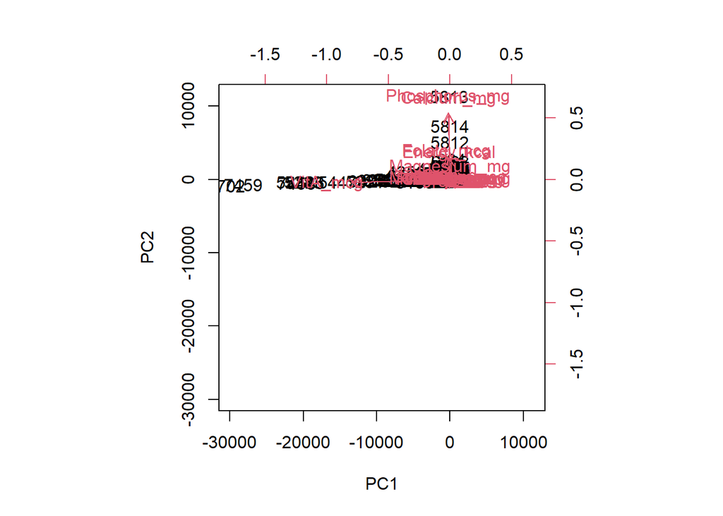

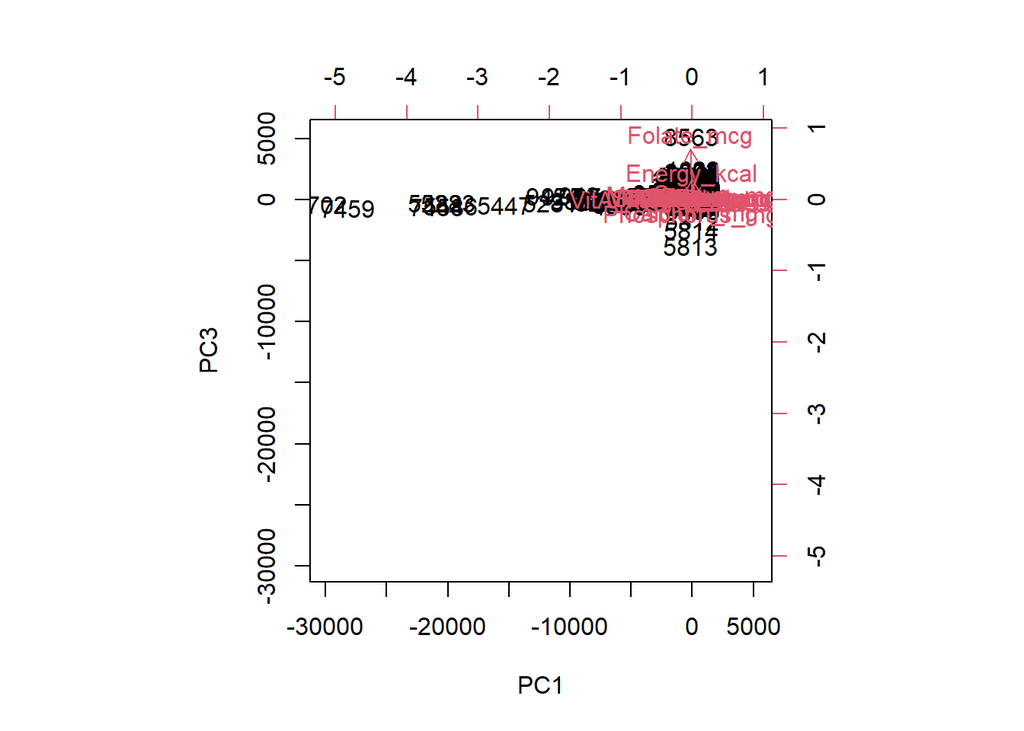

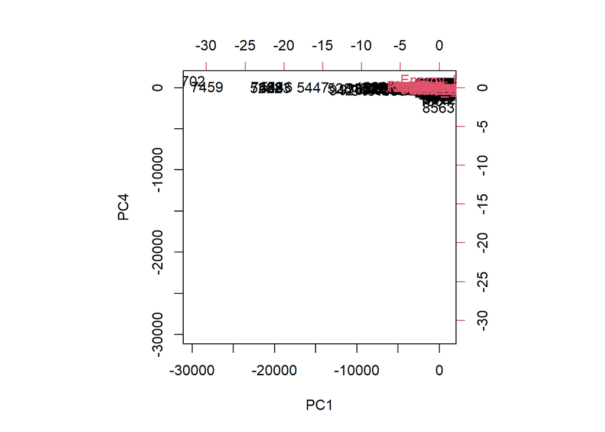

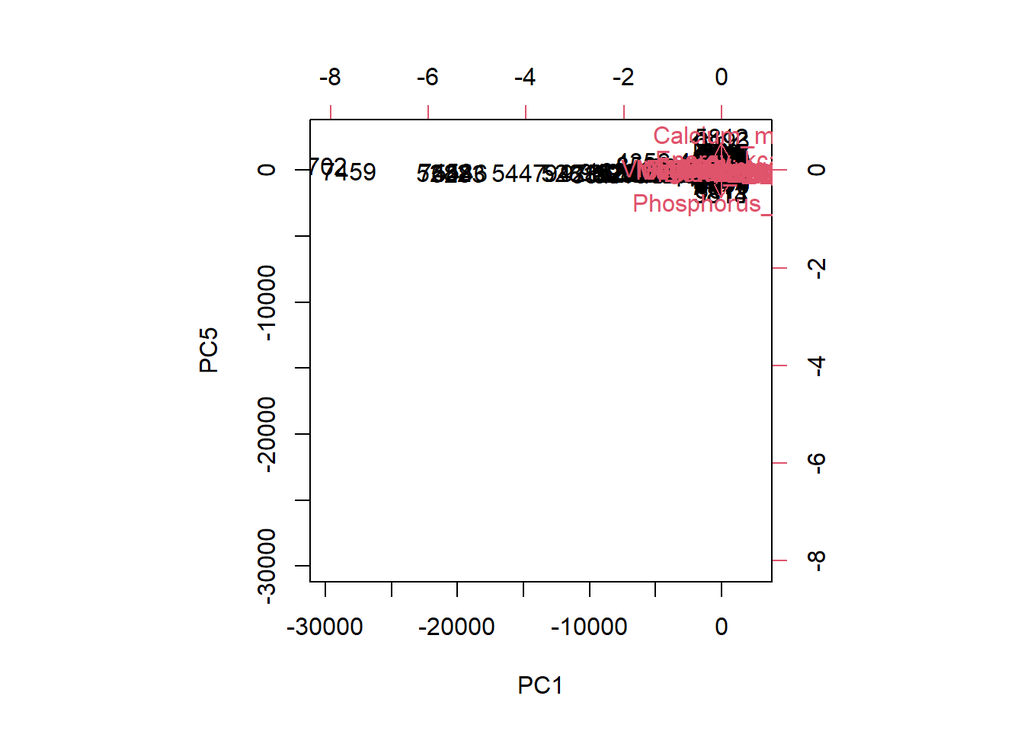

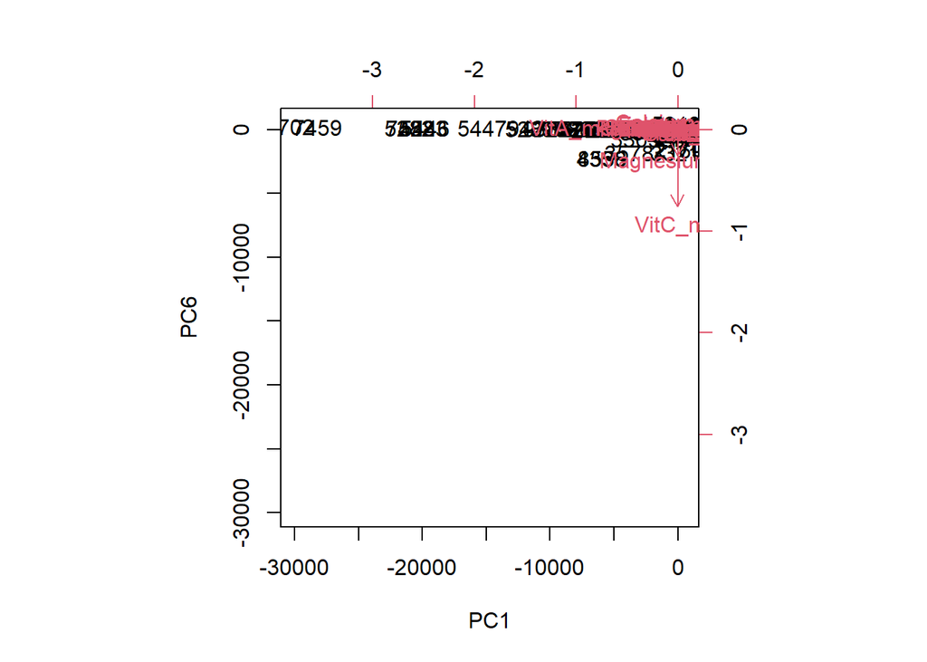

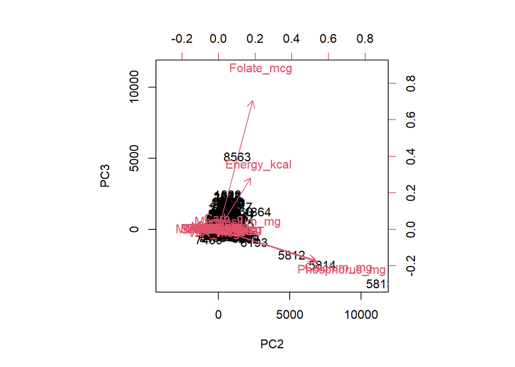

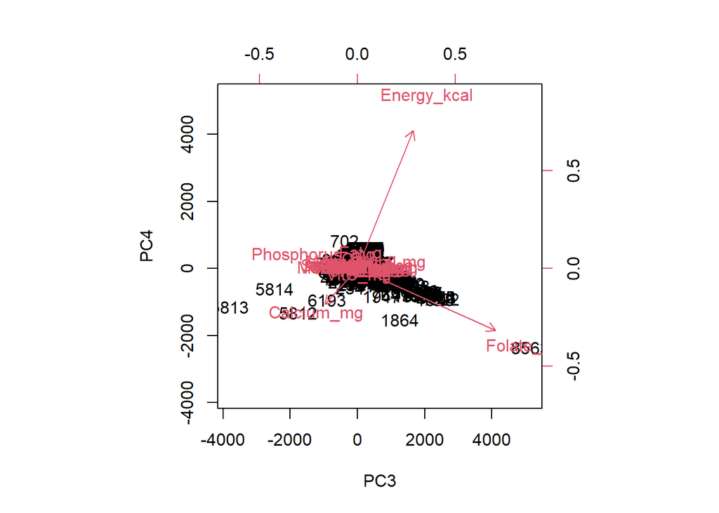

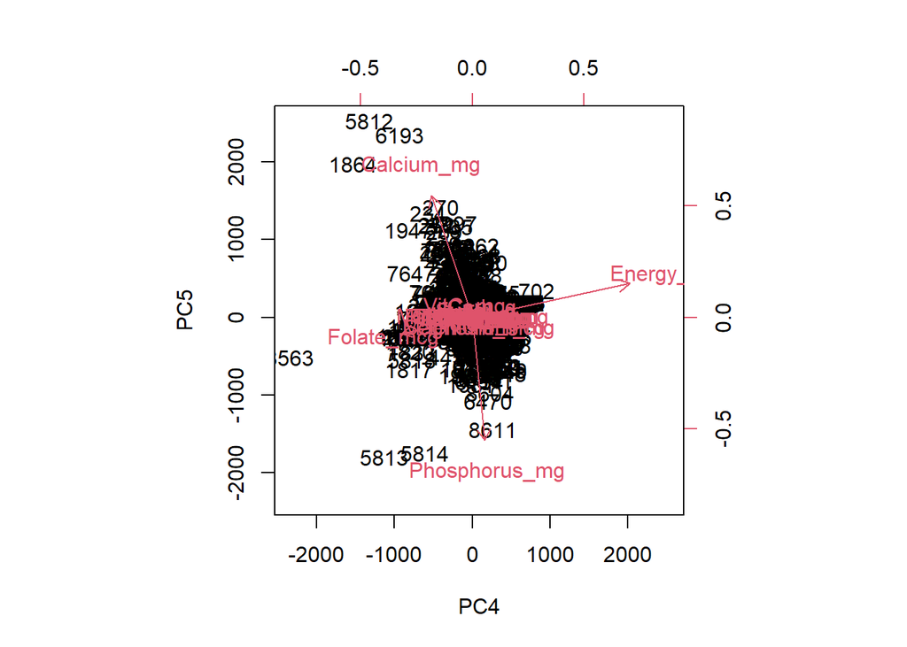

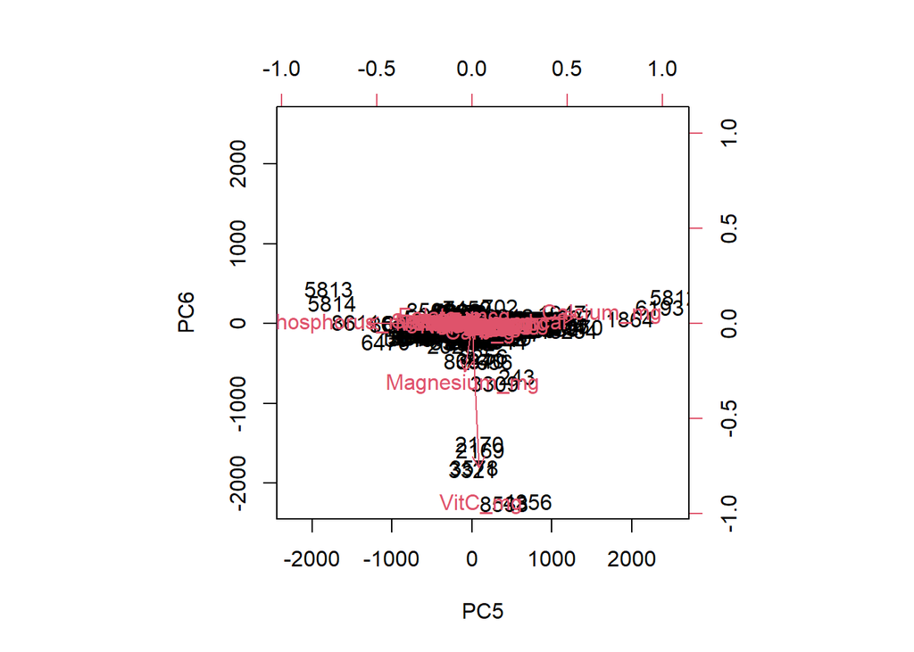

```r
nnpcomp12<-biplot(nnpcomp, c(1,2), scale=0)
nnpcomp13<-biplot(nnpcomp, c(1,3), scale=0)
nnpcomp14<-biplot(nnpcomp, c(1,4), scale=0)
nnpcomp15<-biplot(nnpcomp, c(1,5), scale=0)
nnpcomp16<-biplot(nnpcomp, c(1,6), scale=0)
nnpcomp23<-biplot(nnpcomp, c(2,3), scale=0)
nnpcomp34<-biplot(nnpcomp, c(3,4), scale=0)
nnpcomp45<-biplot(nnpcomp, c(4,5), scale=0)
nnpcomp56<-biplot(nnpcomp, c(5,6), scale=0)
```

**Answer:** Above are the biplots.

### Question 8

**PVE**  
Does the plots show that `PC1` capture much more variance than `PC2`? `PC6`? (Of course we can confirm these with the PVE plot and calculations if we like. It is not required in this hw here.)

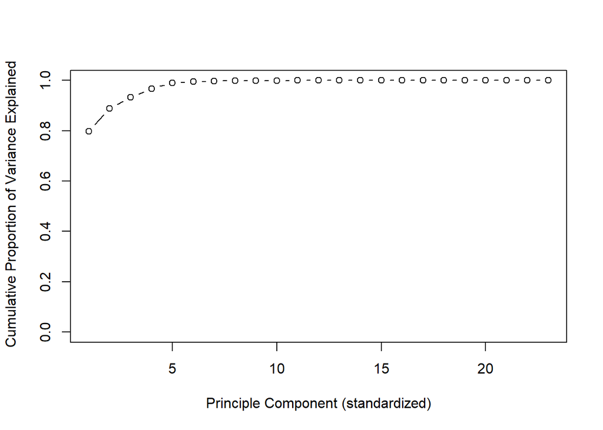

```r
nnpcomp_var<-(nnpcomp$sdev^2)
nnpcomp_pve<-nnpcomp_var/sum(nnpcomp_var)
plot(cumsum(nnpcomp_pve), xlab='Principle Component (standardized)', ylab=' Cumulative Proportion of Variance Explained', ylim=c(0,1), type='b')
```

**Answer:** Most of the variance is captured by PC1, about 0.8, while adding PC2 adds a proportion of variance value of 0.1. Combined PC1 and PC2 capture 90% of the variance. Going all the way up to PC6 captures almost all of the variance.

### Question 9

**Interesting plots**  
If you look at the plot between `PC1` and `PC2`, it looks like a boomerang shape. (See image file in the hw zip.) Recall that `PC1` and `PC2` consists of rather different linear combinations of the original variables. And `PC1`-`PC2` have zero correlation. The chart shows us although `PC1` and `PC2` are overall un-correlated, when `PC1` change, there are only two different trends that `PC2` will change, as if there are only two types of nutrients in the 8000+ observations. Maybe these two kinds of food/items should be analyzed separately with two different models. These are some of the patterns and structures that PCA might be able to reveal.

At any rate, do you see other charts showing unexpected patterns?

## Optional

We will skip the model building using PCR here as it turns out not a productive exercise in that direction. While we are having this huge dataset, with 23 variables, this is actually a good candidate for performing the feature selection using leaps.

If you just look at the dataset and guess what are the good predictors to model Energy_kcal, what would you pick?

Now try run it by leaps regsubsets. What is the minimum number of predictors you will need, if you want to have a 90% $R^2$?